# Survival Analysis Practical

# Preface

## Library

```r
library(pacman)
p_load(haven, dplyr, psych, lubridate, knitr, ggplot2, survival, broom, survminer, mfp)
```

## Dataset

Import dataset

```r
WHASDS <- read_spss("whas500.sav")
WHASDS
```

| id | age | gender | hr | sysbp | diasbp | bmi | cvd | afb | sho | chf | av3 | miord | mitype | year | los | dstat | lenfol | fstat | admitdate | disdate | fdate |
| --- | --- | --- | --- | --- | --- | --- | --- | --- | --- | --- | --- | --- | --- | --- | --- | --- | --- | --- | --- | --- | --- |
| 1 | 83 | 0 | 89 | 152 | 78 | 25.54051 | 1 | 1 | 0 | 0 | 0 | 1 | 0 | 1 | 5 | 0 | 2178 | 0 | 1997-01-13 | 1997-01-18 | 2002-12-31 |
| 2 | 49 | 0 | 84 | 120 | 60 | 24.02398 | 1 | 0 | 0 | 0 | 0 | 0 | 1 | 1 | 5 | 0 | 2172 | 0 | 1997-01-19 | 1997-01-24 | 2002-12-31 |
| 3 | 70 | 1 | 83 | 147 | 88 | 22.14290 | 0 | 0 | 0 | 0 | 0 | 0 | 1 | 1 | 5 | 0 | 2190 | 0 | 1997-01-01 | 1997-01-06 | 2002-12-31 |
| 4 | 70 | 0 | 65 | 123 | 76 | 26.63187 | 1 | 0 | 0 | 1 | 0 | 0 | 1 | 1 | 10 | 0 | 297 | 1 | 1997-02-17 | 1997-02-27 | 1997-12-11 |
| 5 | 70 | 0 | 63 | 135 | 85 | 24.41255 | 1 | 0 | 0 | 0 | 0 | 0 | 1 | 1 | 6 | 0 | 2131 | 0 | 1997-03-01 | 1997-03-07 | 2002-12-31 |
| 6 | 70 | 0 | 76 | 83 | 54 | 23.24236 | 1 | 0 | 0 | 0 | 1 | 0 | 0 | 1 | 1 | 1 | 1 | 1 | 1997-03-11 | 1997-03-12 | 1997-03-12 |
| 7 | 57 | 0 | 73 | 191 | 116 | 39.49046 | 1 | 0 | 0 | 0 | 0 | 0 | 1 | 1 | 5 | 0 | 2122 | 0 | 1997-03-10 | 1997-03-15 | 2002-12-31 |
| 8 | 55 | 0 | 91 | 147 | 95 | 27.11609 | 1 | 0 | 0 | 0 | 0 | 0 | 1 | 1 | 4 | 0 | 1496 | 1 | 1997-01-11 | 1997-01-15 | 2001-02-15 |
| 9 | 88 | 1 | 63 | 209 | 100 | 27.43554 | 1 | 0 | 0 | 1 | 0 | 0 | 0 | 1 | 4 | 0 | 920 | 1 | 1996-12-31 | 1997-01-04 | 1999-07-09 |
| 10 | 54 | 0 | 104 | 166 | 106 | 25.54448 | 1 | 0 | 0 | 0 | 0 | 0 | 0 | 1 | 5 | 0 | 2175 | 0 | 1997-01-16 | 1997-01-21 | 2002-12-31 |

[output cut: 490 more lines]

Convert to categorical data

```r
WHASDS2 <- WHASDS %>%
  mutate(gender = factor(gender,
                         labels = c("male", "female")),
         BMICat = cut(bmi, c(0, 20, 25, 30, 100),
                      labels = c("Underweight", "Normal", "Overweight", "Obese")),
         cvd = factor(cvd,
                      labels = c("No", "Yes")),
         AtrFib = factor(afb,
                         labels = c("No", "Yes")),
         CardioShock = factor(cvd,
                              labels = c("No", "Yes")),
         ConHeartCx = factor(chf,
                             labels = c("No", "Yes")),
         CompHeartBlock = factor(av3,
                                 labels = c("No", "Yes")),
         MIOrder = factor(miord,
                          labels = c("first", "recurrent")),
         MIType = factor(mitype,
                         labels = c("non Q-wave", "Q-wave")),
         DischargeStatus = factor(dstat,
                                  labels = c("alive", "dead")),
         FUpStatus = factor(fstat,
                            labels = c("alive", "dead"))) %>%
  select (id,
          FUpStatus,
          age,
          gender,
          hr,
          sysbp,
          diasbp,
          bmi,
          BMICat,
          CardioShock,
          ConHeartCx,
          CompHeartBlock,
          MIOrder,
          MIType,
          admitdate,
          disdate,
          fdate,
          DischargeStatus)
WHASDS2
```

| id | FUpStatus | age | gender | hr | sysbp | diasbp | bmi | BMICat | CardioShock | ConHeartCx | CompHeartBlock | MIOrder | MIType | admitdate | disdate | fdate | DischargeStatus |
| --- | --- | --- | --- | --- | --- | --- | --- | --- | --- | --- | --- | --- | --- | --- | --- | --- | --- |
| 1 | alive | 83 | male | 89 | 152 | 78 | 25.54051 | Overweight | Yes | No | No | recurrent | non Q-wave | 1997-01-13 | 1997-01-18 | 2002-12-31 | alive |
| 2 | alive | 49 | male | 84 | 120 | 60 | 24.02398 | Normal | Yes | No | No | first | Q-wave | 1997-01-19 | 1997-01-24 | 2002-12-31 | alive |
| 3 | alive | 70 | female | 83 | 147 | 88 | 22.14290 | Normal | No | No | No | first | Q-wave | 1997-01-01 | 1997-01-06 | 2002-12-31 | alive |
| 4 | dead | 70 | male | 65 | 123 | 76 | 26.63187 | Overweight | Yes | Yes | No | first | Q-wave | 1997-02-17 | 1997-02-27 | 1997-12-11 | alive |
| 5 | alive | 70 | male | 63 | 135 | 85 | 24.41255 | Normal | Yes | No | No | first | Q-wave | 1997-03-01 | 1997-03-07 | 2002-12-31 | alive |
| 6 | dead | 70 | male | 76 | 83 | 54 | 23.24236 | Normal | Yes | No | Yes | first | non Q-wave | 1997-03-11 | 1997-03-12 | 1997-03-12 | dead |
| 7 | alive | 57 | male | 73 | 191 | 116 | 39.49046 | Obese | Yes | No | No | first | Q-wave | 1997-03-10 | 1997-03-15 | 2002-12-31 | alive |
| 8 | dead | 55 | male | 91 | 147 | 95 | 27.11609 | Overweight | Yes | No | No | first | Q-wave | 1997-01-11 | 1997-01-15 | 2001-02-15 | alive |
| 9 | dead | 88 | female | 63 | 209 | 100 | 27.43554 | Overweight | Yes | Yes | No | first | non Q-wave | 1996-12-31 | 1997-01-04 | 1999-07-09 | alive |
| 10 | alive | 54 | male | 104 | 166 | 106 | 25.54448 | Overweight | Yes | No | No | first | non Q-wave | 1997-01-16 | 1997-01-21 | 2002-12-31 | alive |

[output cut: 490 more lines]

calculate duration

```r
WHASDS2 <- WHASDS2 %>%
  mutate(dur = as.duration(WHASDS2$admitdate %--% WHASDS2$fdate),
         dur_year = dur/dyears(1)) %>%
  select (id,
          FUpStatus,
          dur_year,
          age,
          gender,
          hr,
          sysbp,
          diasbp,
          bmi,
          BMICat,
          CardioShock,
          ConHeartCx,
          CompHeartBlock,
          MIOrder,
          MIType,
          admitdate,
          disdate,
          fdate,
          DischargeStatus,
          dur)
```

# Descriptive Study

## Summary

summary all data

```r
WHASDS2 %>%
  select_if(is.numeric) %>%
  summary()
```

```
       id           dur_year            age               hr             sysbp
 Min.   :  1.0   Min.   :0.00274   Min.   : 30.00   Min.   : 35.00   Min.   : 57.0
 1st Qu.:125.8   1st Qu.:0.81233   1st Qu.: 59.00   1st Qu.: 69.00   1st Qu.:123.0
 Median :250.5   Median :1.73014   Median : 72.00   Median : 85.00   Median :141.5
 Mean   :250.5   Mean   :2.41763   Mean   : 69.85   Mean   : 87.02   Mean   :144.7
 3rd Qu.:375.2   3rd Qu.:3.73562   3rd Qu.: 82.00   3rd Qu.:100.25   3rd Qu.:164.0
 Max.   :500.0   Max.   :6.46027   Max.   :104.00   Max.   :186.00   Max.   :244.0
     diasbp            bmi             dur
 Min.   :  6.00   Min.   :13.05   Min.   :86400s (~1 days)
 1st Qu.: 63.00   1st Qu.:23.22   1st Qu.:25617600s (~42.36 weeks)
 Median : 79.00   Median :25.95   Median :54561600s (~1.73 years)
 Mean   : 78.27   Mean   :26.61   Mean   :76242470.4s (~2.42 years)
 3rd Qu.: 91.25   3rd Qu.:29.39   3rd Qu.:117806400s (~3.73 years)
 Max.   :198.00   Max.   :44.84   Max.   :203731200s (~6.46 years)
```

```r
WHASDS2 %>%
  select_if(is.factor) %>%
  summary()
```

```
 FUpStatus      gender            BMICat    CardioShock ConHeartCx CompHeartBlock
 alive:285   male  :300   Underweight: 49   No :125     No :345    No :489
 dead :215   female:200   Normal     :149   Yes:375     Yes:155    Yes: 11
                          Overweight :186
                          Obese      :116
      MIOrder           MIType    DischargeStatus
 first    :329   non Q-wave:347   alive:461
 recurrent:171   Q-wave    :153   dead : 39
```

summary all data, group by follow up status **to update**

```r
WHASDS2 %>%
  group_by(FUpStatus) %>%
  select_if(is.numeric) %>%
  summary()
```

```
 FUpStatus         id           dur_year            age               hr
 alive:285   Min.   :  1.0   Min.   :0.00274   Min.   : 30.00   Min.   : 35.00
 dead :215   1st Qu.:125.8   1st Qu.:0.81233   1st Qu.: 59.00   1st Qu.: 69.00
             Median :250.5   Median :1.73014   Median : 72.00   Median : 85.00
             Mean   :250.5   Mean   :2.41763   Mean   : 69.85   Mean   : 87.02
             3rd Qu.:375.2   3rd Qu.:3.73562   3rd Qu.: 82.00   3rd Qu.:100.25
             Max.   :500.0   Max.   :6.46027   Max.   :104.00   Max.   :186.00
     sysbp           diasbp            bmi             dur
 Min.   : 57.0   Min.   :  6.00   Min.   :13.05   Min.   :86400s (~1 days)
 1st Qu.:123.0   1st Qu.: 63.00   1st Qu.:23.22   1st Qu.:25617600s (~42.36 weeks)
 Median :141.5   Median : 79.00   Median :25.95   Median :54561600s (~1.73 years)
 Mean   :144.7   Mean   : 78.27   Mean   :26.61   Mean   :76242470.4s (~2.42 years)
 3rd Qu.:164.0   3rd Qu.: 91.25   3rd Qu.:29.39   3rd Qu.:117806400s (~3.73 years)
 Max.   :244.0   Max.   :198.00   Max.   :44.84   Max.   :203731200s (~6.46 years)
```

```r
WHASDS2 %>%
  group_by(FUpStatus) %>%
  select_if(is.factor) %>%
  summary()
```

```
 FUpStatus      gender            BMICat    CardioShock ConHeartCx CompHeartBlock
 alive:285   male  :300   Underweight: 49   No :125     No :345    No :489
 dead :215   female:200   Normal     :149   Yes:375     Yes:155    Yes: 11
                          Overweight :186
                          Obese      :116
      MIOrder           MIType    DischargeStatus
 first    :329   non Q-wave:347   alive:461
 recurrent:171   Q-wave    :153   dead : 39
```

## Visualization

barchart for all categorical data

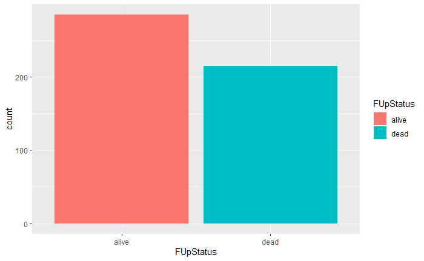

```r
ggplot(WHASDS2, aes(x=FUpStatus, fill=FUpStatus)) +
  geom_bar()
```

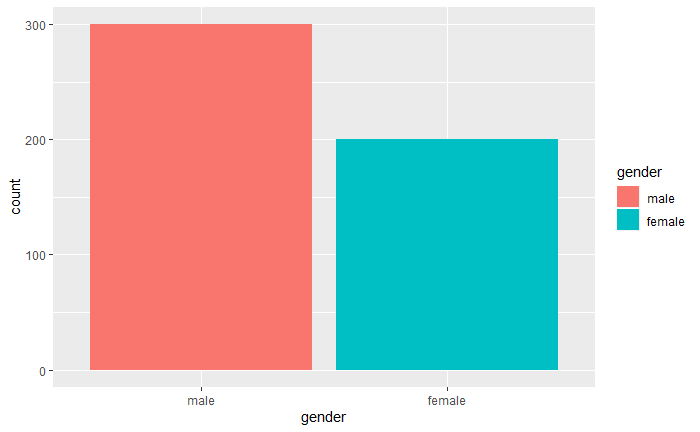

```r
ggplot(WHASDS2, aes(x=gender, fill=gender)) +
  geom_bar()
```

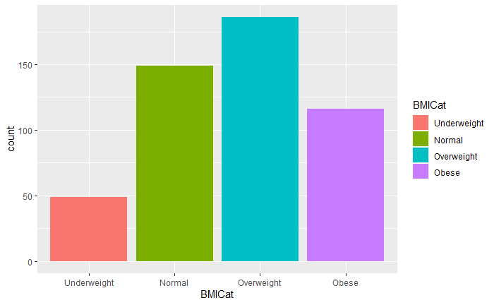

```r
ggplot(WHASDS2, aes(x=BMICat, fill=BMICat)) +
  geom_bar()
```

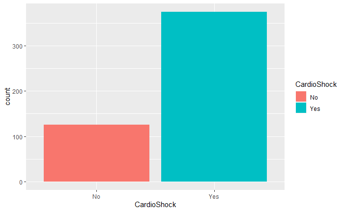

```r
ggplot(WHASDS2, aes(x=CardioShock, fill=CardioShock)) +
  geom_bar()
```

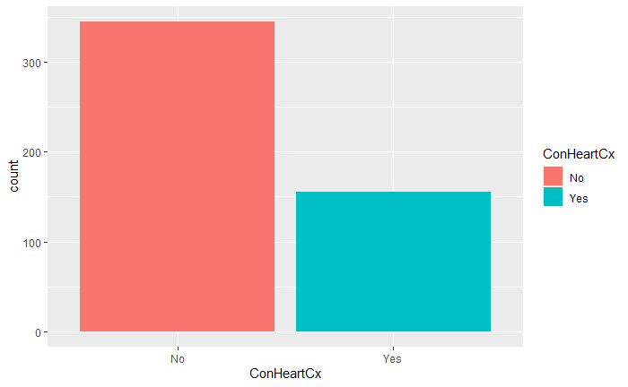

```r
ggplot(WHASDS2, aes(x=ConHeartCx, fill=ConHeartCx)) +
  geom_bar()
```

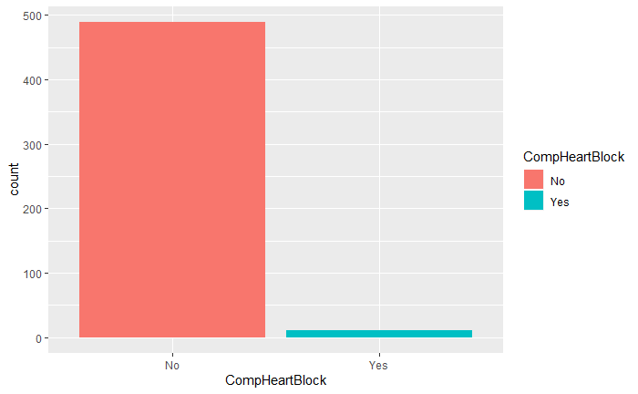

```r
ggplot(WHASDS2, aes(x=CompHeartBlock, fill=CompHeartBlock)) +
  geom_bar()
```

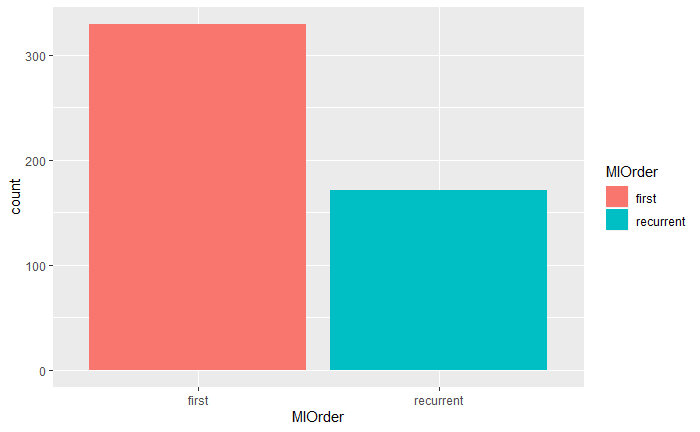

```r
ggplot(WHASDS2, aes(x=MIOrder, fill=MIOrder)) +
  geom_bar()
```

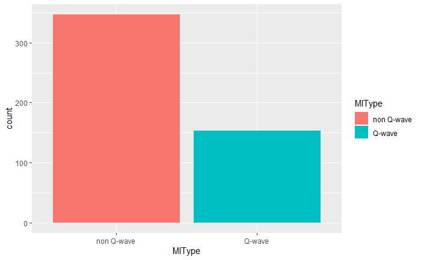

```r
ggplot(WHASDS2, aes(x=MIType, fill=MIType)) +
  geom_bar()
```

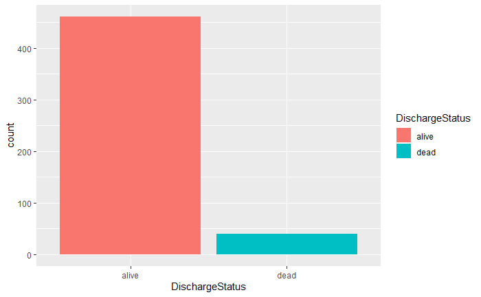

```r
ggplot(WHASDS2, aes(x=DischargeStatus, fill=DischargeStatus)) +
  geom_bar()
```

histogram for all numerical data

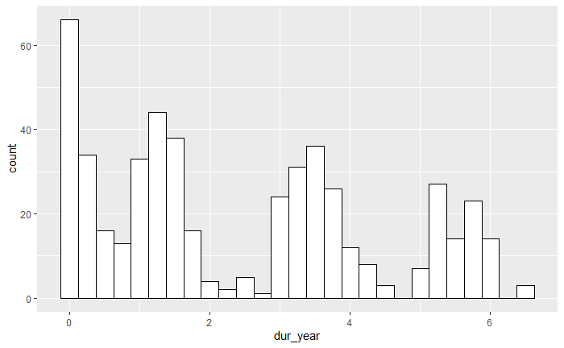

```r
ggplot(WHASDS2, aes(dur_year)) +
  geom_histogram(binwidth=0.25, colour="black", fill="white")
```

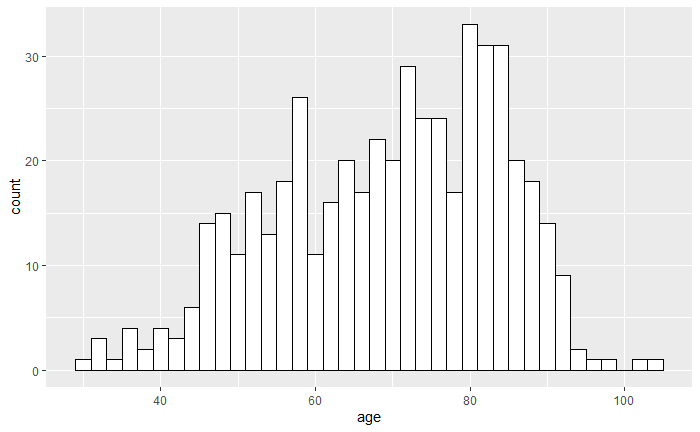

```r
ggplot(WHASDS2, aes(age)) +
  geom_histogram(binwidth=2, colour="black", fill="white")
```

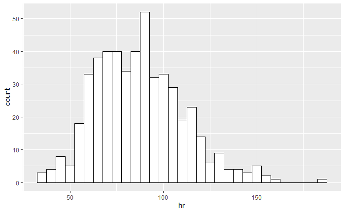

```r
ggplot(WHASDS2, aes(hr)) +
  geom_histogram(binwidth=5, colour="black", fill="white")
```

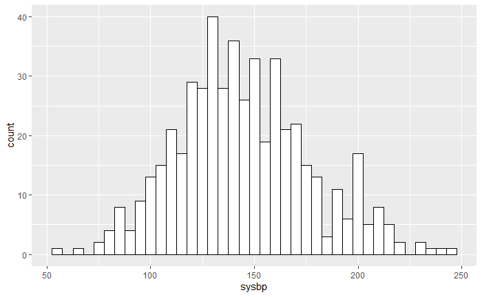

```r
ggplot(WHASDS2, aes(sysbp)) +
  geom_histogram(binwidth=5, colour="black", fill="white")
```

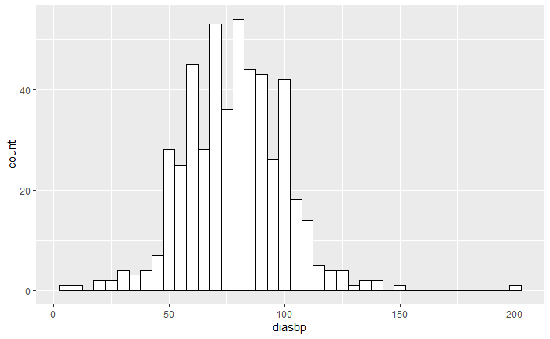

```r
ggplot(WHASDS2, aes(diasbp)) +
  geom_histogram(binwidth=5, colour="black", fill="white")
```

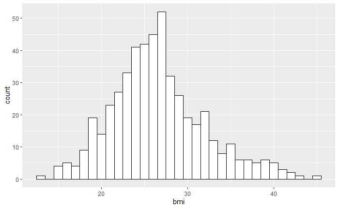

```r
ggplot(WHASDS2, aes(bmi)) +
  geom_histogram(binwidth=1, colour="black", fill="white")
```

Barchart for all categorical data, divide by follow up status

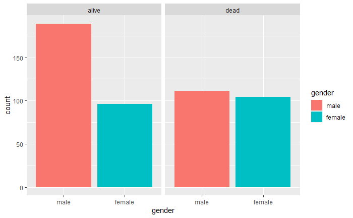

```r
ggplot(WHASDS2, aes(x=gender, fill=gender)) +
  geom_bar() +
  facet_wrap(~FUpStatus)
```

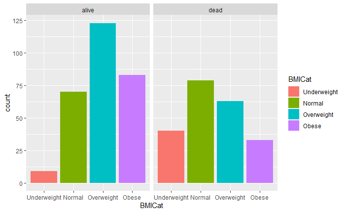

```r
ggplot(WHASDS2, aes(x=BMICat, fill=BMICat)) +
  geom_bar() +
  facet_wrap(~FUpStatus)
```

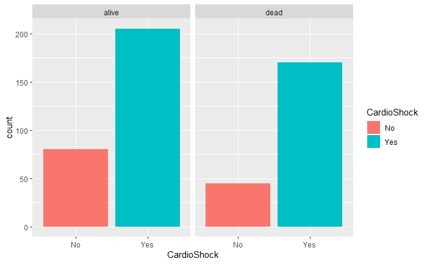

```r
ggplot(WHASDS2, aes(x=CardioShock, fill=CardioShock)) +
  geom_bar() +
  facet_wrap(~FUpStatus)
```

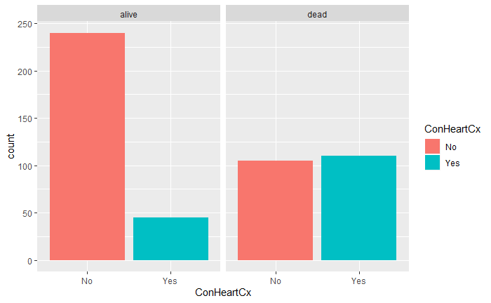

```r
ggplot(WHASDS2, aes(x=ConHeartCx, fill=ConHeartCx)) +
  geom_bar() +
  facet_wrap(~FUpStatus)
```

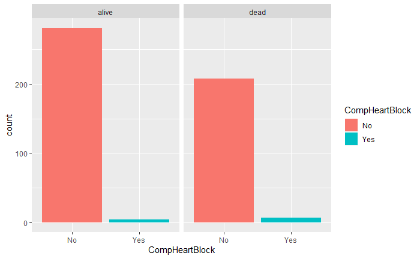

```r
ggplot(WHASDS2, aes(x=CompHeartBlock, fill=CompHeartBlock)) +
  geom_bar() +
  facet_wrap(~FUpStatus)
```

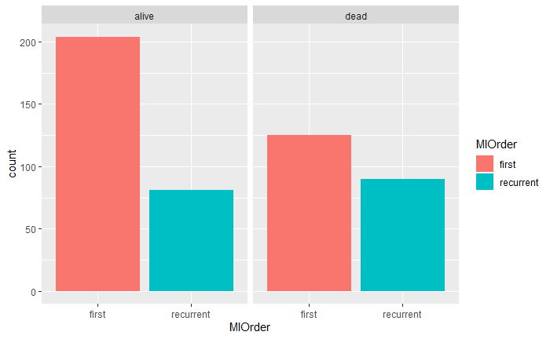

```r
ggplot(WHASDS2, aes(x=MIOrder, fill=MIOrder)) +
  geom_bar() +
  facet_wrap(~FUpStatus)
```

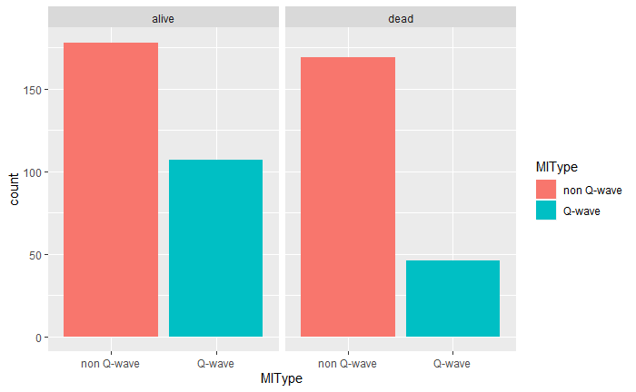

```r
ggplot(WHASDS2, aes(x=MIType, fill=MIType)) +
  geom_bar() +
  facet_wrap(~FUpStatus)
```

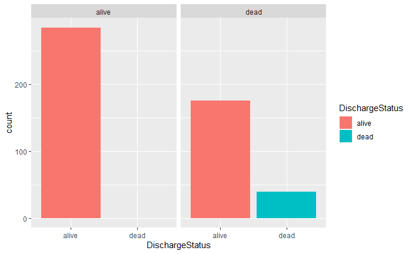

```r
ggplot(WHASDS2, aes(x=DischargeStatus, fill=DischargeStatus)) +
  geom_bar() +
  facet_wrap(~FUpStatus)
```

histogram for all numerical data, divide by follow up status

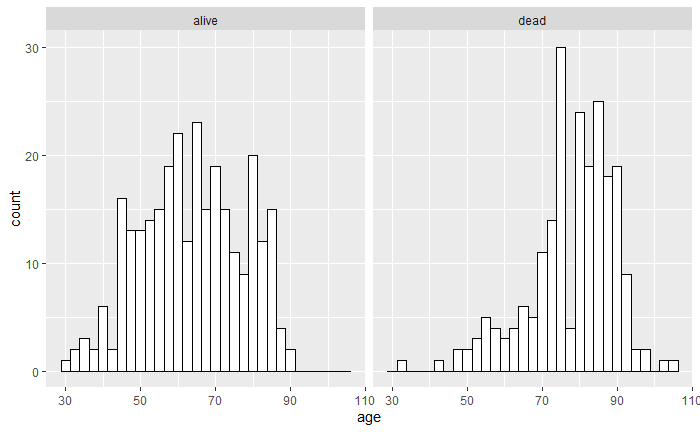

```r
ggplot(WHASDS2, aes(age)) +
  geom_histogram(binwidth=2.5, colour="black", fill="white") +
  facet_wrap(~FUpStatus)
```

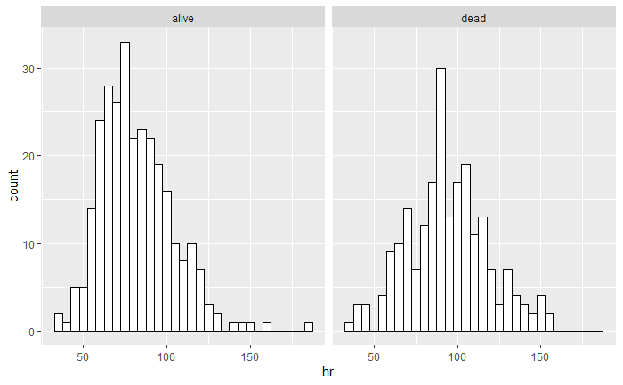

```r
ggplot(WHASDS2, aes(hr)) +
  geom_histogram(binwidth=5, colour="black", fill="white") +
  facet_wrap(~FUpStatus)
```

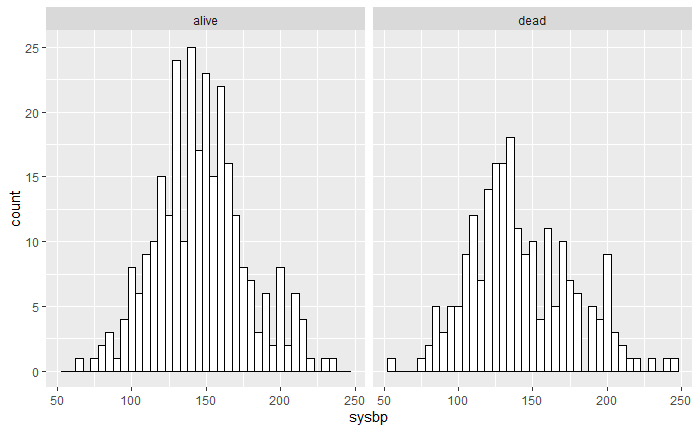

```r
ggplot(WHASDS2, aes(sysbp)) +
  geom_histogram(binwidth=5, colour="black", fill="white") +
  facet_wrap(~FUpStatus)
```

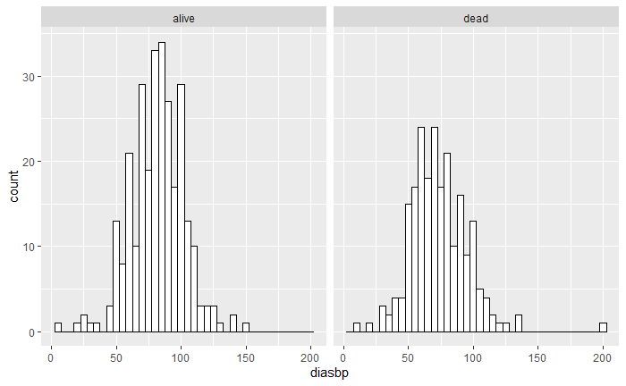

```r
ggplot(WHASDS2, aes(diasbp)) +
  geom_histogram(binwidth=5, colour="black", fill="white") +
  facet_wrap(~FUpStatus)
```

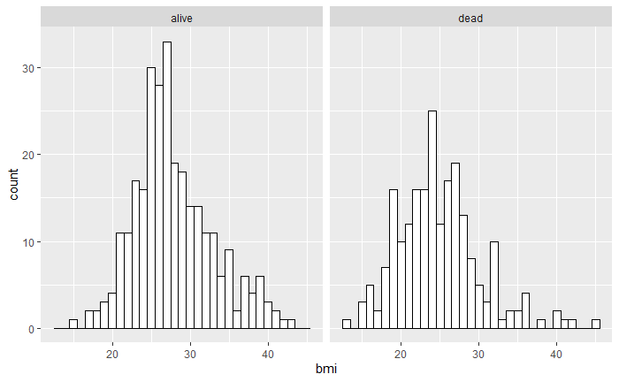

```r
ggplot(WHASDS2, aes(bmi)) +
  geom_histogram(binwidth=1, colour="black", fill="white") +
  facet_wrap(~FUpStatus)
```

## KM Estimate

```r
Overall_KM <- survfit(Surv(time = dur_year, FUpStatus == "dead") ~1,
                      data = WHASDS2,
                      type = "kaplan-meier")
Overall_KM
```

```
Call: survfit(formula = Surv(time = dur_year, FUpStatus == "dead") ~
    1, data = WHASDS2, type = "kaplan-meier")

      n  events  median 0.95LCL 0.95UCL
 500.00  215.00    4.46    4.18      NA
```

## KM Plot

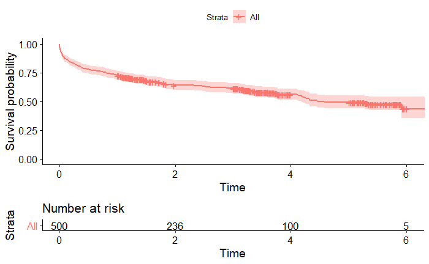

```r
ggsurvplot(Overall_KM,
           data = WHASDS2,
           risk.table = T)
```

## Estimate survival time

estimating survival time, at 25th percentile survival probability, median survival probability and 75th percentile survival probability

```r
quantile(Overall_KM, probs = c(0.25, 0.5, 0.75))
```

```
$quantile
       25        50        75
0.8109589 4.4575342 6.4465753

$lower
       25        50        75
0.4547945 4.1835616 6.4383562

$upper
      25       50       75
1.156164       NA       NA
```

## Survival Probability

```r
summary(Overall_KM, times = c(0.5, 1, 3, 5))
```

```
Call: survfit(formula = Surv(time = dur_year, FUpStatus == "dead") ~
    1, data = WHASDS2, type = "kaplan-meier")

 time n.risk n.event survival std.err lower 95% CI upper 95% CI
  0.5    390     110    0.780  0.0185        0.745        0.817
  1.0    362      28    0.724  0.0200        0.686        0.764
  3.0    226      44    0.614  0.0229        0.571        0.661
  5.0     88      27    0.494  0.0285        0.441        0.553
```

# Univariable

## Univariable - Age

### Cox Proportional Hazard

```r
age_CPH <- coxph(Surv(time = dur_year, FUpStatus == "dead") ~age,
                 data = WHASDS2)
age_CPH
```

```
Call:
coxph(formula = Surv(time = dur_year, FUpStatus == "dead") ~
    age, data = WHASDS2)

        coef exp(coef) se(coef)     z      p
age 0.066339  1.068589 0.006079 10.91 <2e-16

Likelihood ratio test=142.1  on 1 df, p=< 2.2e-16
n= 500, number of events= 215
```

```r
tidy(age_CPH)
```

| term | estimate | std.error | statistic | p.value | conf.low | conf.high |
| --- | --- | --- | --- | --- | --- | --- |
| age | 0.06633895 | 0.006079292 | 10.91228 | 1.006955e-27 | 0.05442376 | 0.07825415 |

## Univariable - Gender

### KM Estimate

```r
gender_KM <- survfit(Surv(time = dur_year, FUpStatus == "dead") ~gender,
                      data = WHASDS2,
                      type = "kaplan-meier")
```

### KM Plot

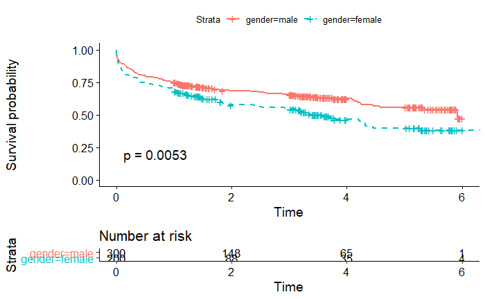

```r
ggsurvplot(gender_KM,
           data = WHASDS2,
           risk.table = T,
           linetype = c(1,2),
           pval = T)
```

### Log Rank Test

```r
gender_LR <- survdiff(Surv(time = dur_year, FUpStatus == "dead") ~gender,
                      data = WHASDS2,
                      rho = 0)
gender_LR
```

```
Call:
survdiff(formula = Surv(time = dur_year, FUpStatus == "dead") ~
    gender, data = WHASDS2, rho = 0)

                N Observed Expected (O-E)^2/E (O-E)^2/V
gender=male   300      111    130.7      2.98      7.79
gender=female 200      104     84.3      4.62      7.79

 Chisq= 7.8  on 1 degrees of freedom, p= 0.005
```

### Cox Proportional Hazard

```r
gender_CPH <- coxph(Surv(time = dur_year, FUpStatus == "dead") ~gender,
                 data = WHASDS2)
gender_CPH
```

```
Call:
coxph(formula = Surv(time = dur_year, FUpStatus == "dead") ~
    gender, data = WHASDS2)

               coef exp(coef) se(coef)     z       p
genderfemale 0.3815    1.4645   0.1376 2.773 0.00556

Likelihood ratio test=7.6  on 1 df, p=0.005843
n= 500, number of events= 215
```

```r
tidy(gender_CPH)
```

| term | estimate | std.error | statistic | p.value | conf.low | conf.high |
| --- | --- | --- | --- | --- | --- | --- |
| genderfemale | 0.381512 | 0.1375836 | 2.772946 | 0.005555126 | 0.1118531 | 0.651171 |

### Survival Time Estimation

estimating survival time, at 25th percentile survival probability, median survival probability and 75th percentile survival probability

```r
quantile(gender_KM, probs = c(0.25, 0.5, 0.75))
```

```
$quantile
                     25       50       75
gender=male   1.0082192 5.917808       NA
gender=female 0.4767123 3.608219 6.446575

$lower
                     25       50       75
gender=male   0.5123288 4.578082       NA
gender=female 0.2273973 2.479452 6.438356

$upper
                    25       50 75
gender=male   1.764384       NA NA
gender=female 1.054795 4.457534 NA
```

## Univariable - Heart Rate

### Cox Proportional Hazard

```r
hr_CPH <- coxph(Surv(time = dur_year, FUpStatus == "dead") ~hr,
                 data = WHASDS2)
hr_CPH
```

```
Call:
coxph(formula = Surv(time = dur_year, FUpStatus == "dead") ~
    hr, data = WHASDS2)

       coef exp(coef) se(coef)     z        p
hr 0.015051  1.015165 0.002687 5.601 2.13e-08

Likelihood ratio test=28.94  on 1 df, p=7.448e-08
n= 500, number of events= 215
```

```r
tidy(hr_CPH)
```

| term | estimate | std.error | statistic | p.value | conf.low | conf.high |
| --- | --- | --- | --- | --- | --- | --- |
| hr | 0.01505111 | 0.002687006 | 5.601442 | 2.125756e-08 | 0.009784675 | 0.02031755 |

## Univariable - Systolic BP

### Cox Proportional Hazard

```r
SBP_CPH <- coxph(Surv(time = dur_year, FUpStatus == "dead") ~sysbp,
                 data = WHASDS2)
SBP_CPH
```

```
Call:
coxph(formula = Surv(time = dur_year, FUpStatus == "dead") ~
    sysbp, data = WHASDS2)

           coef exp(coef)  se(coef)     z      p
sysbp -0.004520  0.995490  0.002226 -2.03 0.0423

Likelihood ratio test=4.19  on 1 df, p=0.04058
n= 500, number of events= 215
```

```r
tidy(SBP_CPH)
```

| term | estimate | std.error | statistic | p.value | conf.low | conf.high |
| --- | --- | --- | --- | --- | --- | --- |
| sysbp | -0.004520436 | 0.002226413 | -2.030367 | 0.04231924 | -0.008884125 | -0.0001567464 |

## Univariable - Diastolic BP

### Cox Proportional Hazard

```r
DBP_CPH <- coxph(Surv(time = dur_year, FUpStatus == "dead") ~diasbp,
                 data = WHASDS2)
DBP_CPH
```

```
Call:
coxph(formula = Surv(time = dur_year, FUpStatus == "dead") ~
    diasbp, data = WHASDS2)

            coef exp(coef)  se(coef)      z        p
diasbp -0.016015  0.984112  0.003284 -4.877 1.08e-06

Likelihood ratio test=23.81  on 1 df, p=1.065e-06
n= 500, number of events= 215
```

```r
tidy(DBP_CPH)
```

| term | estimate | std.error | statistic | p.value | conf.low | conf.high |
| --- | --- | --- | --- | --- | --- | --- |
| diasbp | -0.01601547 | 0.00328387 | -4.877011 | 1.077057e-06 | -0.02245173 | -0.009579201 |

## Univariable - BMI

### Cox Proportional Hazard

```r
BMI_CPH <- coxph(Surv(time = dur_year, FUpStatus == "dead") ~bmi,
                 data = WHASDS2)
BMI_CPH
```

```
Call:
coxph(formula = Surv(time = dur_year, FUpStatus == "dead") ~
    bmi, data = WHASDS2)

        coef exp(coef) se(coef)      z        p
bmi -0.09847   0.90622  0.01475 -6.676 2.46e-11

Likelihood ratio test=48.33  on 1 df, p=3.602e-12
n= 500, number of events= 215
```

```r
tidy(BMI_CPH)
```

| term | estimate | std.error | statistic | p.value | conf.low | conf.high |
| --- | --- | --- | --- | --- | --- | --- |
| bmi | -0.09847287 | 0.01475073 | -6.675796 | 2.45893e-11 | -0.1273838 | -0.06956197 |

## Univariable - BMI (Category)

### KM Estimate

```r
BMICat_KM <- survfit(Surv(time = dur_year, FUpStatus == "dead") ~BMICat,
                      data = WHASDS2,
                      type = "kaplan-meier")
```

### KM Plot

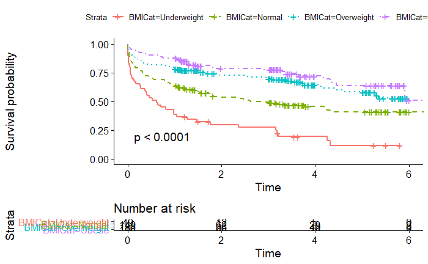

```r
ggsurvplot(BMICat_KM,
           data = WHASDS2,
           risk.table = T,
           linetype = c(1,2,3,4),
           pval = T)
```

### Log Rank Test

```r
BMICat_LR <- survdiff(Surv(time = dur_year, FUpStatus == "dead") ~BMICat,
                      data = WHASDS2,
                      rho = 0)
BMICat_LR
```

```
Call:
survdiff(formula = Surv(time = dur_year, FUpStatus == "dead") ~
    BMICat, data = WHASDS2, rho = 0)

                     N Observed Expected (O-E)^2/E (O-E)^2/V
BMICat=Underweight  49       40     14.4     45.74     49.49
BMICat=Normal      149       79     60.0      6.05      8.45
BMICat=Overweight  186       63     82.9      4.79      7.90
BMICat=Obese       116       33     57.7     10.60     14.82

 Chisq= 68.1  on 3 degrees of freedom, p= 1e-14
```

### Cox Proportional Hazard

```r
BMICat_CPH <- coxph(Surv(time = dur_year, FUpStatus == "dead") ~BMICat,
                 data = WHASDS2)
BMICat_CPH
```

```
Call:
coxph(formula = Surv(time = dur_year, FUpStatus == "dead") ~
    BMICat, data = WHASDS2)

                    coef exp(coef) se(coef)      z        p
BMICatNormal     -0.7634    0.4661   0.1952 -3.911 9.18e-05
BMICatOverweight -1.3156    0.2683   0.2033 -6.472 9.67e-11
BMICatObese      -1.6187    0.1982   0.2389 -6.774 1.25e-11

Likelihood ratio test=54.88  on 3 df, p=7.285e-12
n= 500, number of events= 215
```

```r
tidy(BMICat_CPH)
```

| term | estimate | std.error | statistic | p.value | conf.low | conf.high |
| --- | --- | --- | --- | --- | --- | --- |
| BMICatNormal | -0.7634156 | 0.1951865 | -3.911211 | 9.183457e-05 | -1.145974 | -0.3808571 |
| BMICatOverweight | -1.3155689 | 0.2032725 | -6.471946 | 9.674876e-11 | -1.713976 | -0.9171620 |
| BMICatObese | -1.6186530 | 0.2389413 | -6.774269 | 1.250364e-11 | -2.086969 | -1.1503366 |

### Survival Time Estimation

estimating survival time, at 25th percentile survival probability, median survival probability and 75th percentile survival probability

```r
quantile(BMICat_KM, probs = c(0.25, 0.5, 0.75))
```

```
$quantile
                           25        50       75
BMICat=Underweight 0.05479452 0.6191781 3.156164
BMICat=Normal      0.36712329 2.9178082 6.446575
BMICat=Overweight  1.68219178        NA       NA
BMICat=Obese       3.37534247 6.4383562 6.460274

$lower
                           25        50       75
BMICat=Underweight 0.01643836 0.2767123 1.273973
BMICat=Normal      0.15616438 1.7315068       NA
BMICat=Overweight  0.85753425 4.5780822       NA
BMICat=Obese       1.45205479 5.9178082 6.438356

$upper
                          25       50 75
BMICat=Underweight 0.3698630 1.471233 NA
BMICat=Normal      0.8547945       NA NA
BMICat=Overweight  3.5041096       NA NA
BMICat=Obese              NA       NA NA
```

### KM Estimate

```r
CardioShock_KM <- survfit(Surv(time = dur_year, FUpStatus == "dead") ~CardioShock,
                      data = WHASDS2,
                      type = "kaplan-meier")
```

### KM Plot

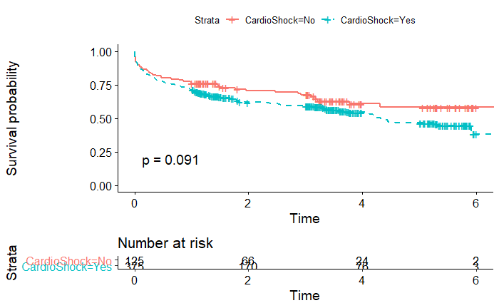

```r
ggsurvplot(CardioShock_KM,
           data = WHASDS2,
           risk.table = T,
           linetype = c(1,2),
           pval = T)
```

### Log Rank Test

```r
CardioShock_LR <- survdiff(Surv(time = dur_year, FUpStatus == "dead") ~CardioShock,
                      data = WHASDS2,
                      rho = 0)
CardioShock_LR
```

```
Call:
survdiff(formula = Surv(time = dur_year, FUpStatus == "dead") ~
    CardioShock, data = WHASDS2, rho = 0)

                  N Observed Expected (O-E)^2/E (O-E)^2/V
CardioShock=No  125       45     55.8     2.104      2.86
CardioShock=Yes 375      170    159.2     0.738      2.86

 Chisq= 2.9  on 1 degrees of freedom, p= 0.09
```

### Cox Proportional Hazard

```r
CardioShock_CPH <- coxph(Surv(time = dur_year, FUpStatus == "dead") ~CardioShock,
                 data = WHASDS2)
CardioShock_CPH
```

```
Call:
coxph(formula = Surv(time = dur_year, FUpStatus == "dead") ~
    CardioShock, data = WHASDS2)

                 coef exp(coef) se(coef)     z      p
CardioShockYes 0.2829    1.3269   0.1680 1.684 0.0922

Likelihood ratio test=2.99  on 1 df, p=0.08377
n= 500, number of events= 215
```

```r
tidy(CardioShock_CPH)
```

| term | estimate | std.error | statistic | p.value | conf.low | conf.high |
| --- | --- | --- | --- | --- | --- | --- |
| CardioShockYes | 0.2828612 | 0.1679555 | 1.684144 | 0.09215383 | -0.04632547 | 0.6120478 |

### Survival Time Estimation

estimating survival time, at 25th percentile survival probability, median survival probability and 75th percentile survival probability

```r
quantile(CardioShock_KM, probs = c(0.25, 0.5, 0.75))
```

```
$quantile
                      25       50       75
CardioShock=No  1.452055 6.446575 6.446575
CardioShock=Yes 0.709589 4.320548 6.438356

$lower
                       25       50       75
CardioShock=No  0.4630137 4.317808       NA
CardioShock=Yes 0.3835616 3.723288 6.438356

$upper
                      25 50 75
CardioShock=No  3.175342 NA NA
CardioShock=Yes 1.087671 NA NA
```

## Univariable - Type of Congestive Heart Complication

### KM Estimate

```r
CHF_KM <- survfit(Surv(time = dur_year, FUpStatus == "dead") ~ConHeartCx,
                      data = WHASDS2,
                      type = "kaplan-meier")
```

### KM Plot

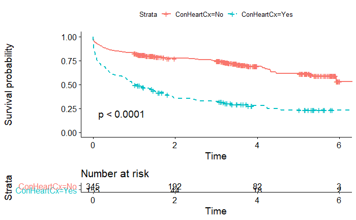

```r
ggsurvplot(CHF_KM,
           data = WHASDS2,
           risk.table = T,
           linetype = c(1,2),
           pval = T)
```

### Log Rank Test

```r
CHF_LR <- survdiff(Surv(time = dur_year, FUpStatus == "dead") ~ConHeartCx,
                      data = WHASDS2,
                      rho = 0)
CHF_LR
```

```
Call:
survdiff(formula = Surv(time = dur_year, FUpStatus == "dead") ~
    ConHeartCx, data = WHASDS2, rho = 0)

                 N Observed Expected (O-E)^2/E (O-E)^2/V
ConHeartCx=No  345      105    162.4      20.3      84.6
ConHeartCx=Yes 155      110     52.6      62.6      84.6

 Chisq= 84.6  on 1 degrees of freedom, p= <2e-16
```

### Cox Proportional Hazard

```r
CHF_CPH <- coxph(Surv(time = dur_year, FUpStatus == "dead") ~ConHeartCx,
                 data = WHASDS2)
CHF_CPH
```

```
Call:
coxph(formula = Surv(time = dur_year, FUpStatus == "dead") ~
    ConHeartCx, data = WHASDS2)

               coef exp(coef) se(coef)     z      p
ConHeartCxYes 1.200     3.319    0.138 8.692 <2e-16

Likelihood ratio test=72.28  on 1 df, p=< 2.2e-16
n= 500, number of events= 215
```

```r
tidy(CHF_CPH)
```

| term | estimate | std.error | statistic | p.value | conf.low | conf.high |
| --- | --- | --- | --- | --- | --- | --- |
| ConHeartCxYes | 1.199694 | 0.1380194 | 8.692213 | 3.554472e-18 | 0.9291809 | 1.470207 |

### Survival Time Estimation at Q1, median and Q3 survival probability

estimating survival time, at 25th percentile survival probability, median survival probability and 75th percentile survival probability

```r
quantile(CHF_KM, probs = c(0.25, 0.5, 0.75))
```

```
$quantile
                      25        50       75
ConHeartCx=No  3.0027397 6.4602740 6.460274
ConHeartCx=Yes 0.1013699 0.9835616 4.241096

$lower
                       25        50       75
ConHeartCx=No  1.53150685 5.9178082       NA
ConHeartCx=Yes 0.05205479 0.7863014 3.156164

$upper
                      25       50 75
ConHeartCx=No  3.7726027       NA NA
ConHeartCx=Yes 0.2986301 1.731507 NA
```

## Univariable - Type of Complete Heart Block

### KM Estimate

```r
CHB_KM <- survfit(Surv(time = dur_year, FUpStatus == "dead") ~CompHeartBlock,
                      data = WHASDS2,
                      type = "kaplan-meier")
```

### KM Plot

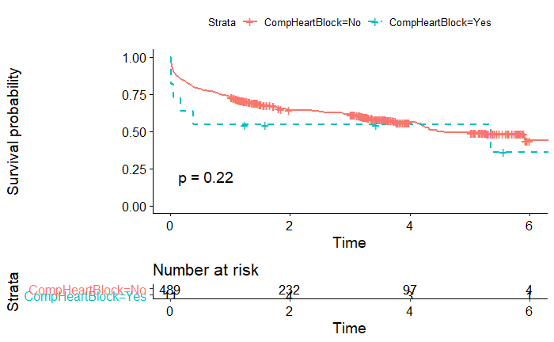

```r
ggsurvplot(CHB_KM,
           data = WHASDS2,
           risk.table = T,
           linetype = c(1,2),
           pval = T)
```

### Log Rank Test

```r
CHB_LR <- survdiff(Surv(time = dur_year, FUpStatus == "dead") ~CompHeartBlock,
                      data = WHASDS2,
                      rho = 0)
CHB_LR
```

```
Call:
survdiff(formula = Surv(time = dur_year, FUpStatus == "dead") ~
    CompHeartBlock, data = WHASDS2, rho = 0)

                     N Observed Expected (O-E)^2/E (O-E)^2/V
CompHeartBlock=No  489      208   210.54    0.0307      1.52
CompHeartBlock=Yes  11        7     4.46    1.4517      1.52

 Chisq= 1.5  on 1 degrees of freedom, p= 0.2
```

### Cox Proportional Hazard

```r
CHB_CPH <- coxph(Surv(time = dur_year, FUpStatus == "dead") ~CompHeartBlock,
                 data = WHASDS2)
CHB_CPH
```

```
Call:
coxph(formula = Surv(time = dur_year, FUpStatus == "dead") ~
    CompHeartBlock, data = WHASDS2)

                    coef exp(coef) se(coef)     z     p
CompHeartBlockYes 0.4789    1.6144   0.3899 1.228 0.219

Likelihood ratio test=1.31  on 1 df, p=0.252
n= 500, number of events= 215
```

```r
tidy(CHB_CPH)
```

| term | estimate | std.error | statistic | p.value | conf.low | conf.high |
| --- | --- | --- | --- | --- | --- | --- |
| CompHeartBlockYes | 0.4789464 | 0.3899281 | 1.228294 | 0.2193366 | -0.2852987 | 1.243191 |

### Survival Time Estimation at Q1, median and Q3 survival probability

estimating survival time, at 25th percentile survival probability, median survival probability and 75th percentile survival probability

```r
quantile(CHB_KM, probs = c(0.25, 0.5, 0.75))
```

```
$quantile
                           25       50       75
CompHeartBlock=No  0.85479452 4.457534 6.446575
CompHeartBlock=Yes 0.05479452 5.353425 6.438356

$lower
                            25        50       75
CompHeartBlock=No  0.463013699 4.1835616 6.446575
CompHeartBlock=Yes 0.005479452 0.1671233 5.353425

$upper
                         25 50 75
CompHeartBlock=No  1.221918 NA NA
CompHeartBlock=Yes       NA NA NA
```

## Univariable - Type of MI Order

### KM Estimate

```r
MIOrder_KM <- survfit(Surv(time = dur_year, FUpStatus == "dead") ~MIOrder,
                      data = WHASDS2,
                      type = "kaplan-meier")
```

### KM Plot

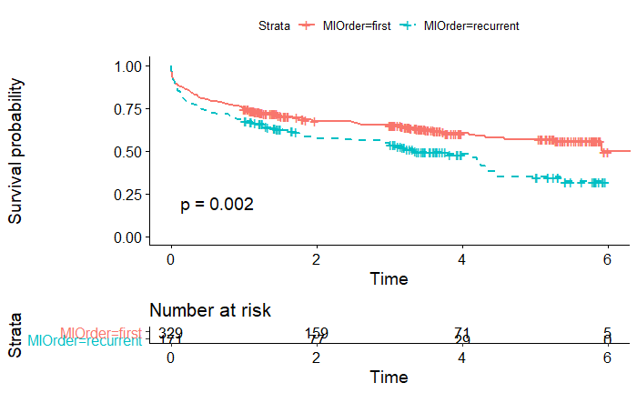

```r
ggsurvplot(MIOrder_KM,
           data = WHASDS2,
           risk.table = T,
           linetype = c(1,2),
           pval = T)
```

### Log Rank Test

```r
MIOrder_LR <- survdiff(Surv(time = dur_year, FUpStatus == "dead") ~MIOrder,
                      data = WHASDS2,
                      rho = 0)
MIOrder_LR
```

```
Call:
survdiff(formula = Surv(time = dur_year, FUpStatus == "dead") ~
    MIOrder, data = WHASDS2, rho = 0)

                    N Observed Expected (O-E)^2/E (O-E)^2/V
MIOrder=first     329      125    146.1      3.04      9.57
MIOrder=recurrent 171       90     68.9      6.43      9.57

 Chisq= 9.6  on 1 degrees of freedom, p= 0.002
```